# Part II - (Prosper Loan Data Presentation)

## by (Ibiwoye Bisola)

## Investigation Overview

> My exploration was guided with a leading question "What factors affects the annual percentage rate (BorrowerAPR)" thus i explored the relationship between BorrowerAPR and loan amount, Prosper score, loan term, employment status. I discovered loan amount is one of the determining factors of BorrowerAPR, as amount increases the BorrowerAPR reduces. The BorrowerRate structure is similar to the BorrowerAPR, BorrowerAPR is BorrowerRate plus other fees and charges. The prosper score which is a determinant of credit worthiness influences the loan amount and resultantly influence the BorrowerAPR. Most people fall under the 36 months loan term category.

## Dataset Overview

> The data set contained 113937 entries arranged in the rows and 81 variables partitioned into columns. Some columns were selected from the dataset for easy exploration. The main feature of interest was the annual percentage rate (BorrowerAPR).

## (Visualization 1)

> Plot a scatter plot to show the relationship between loan amount and annual percentage rate.

> Lower amount has higher rate while higher amount has lower rate, with values below 5000 having the highest rate. This means Loan amount and Borrower's annual percentage rate are negatively correlated, as amount increases, the APR reduces and vice-versa. Real life interpretation of Prosper data mean people who borrow higher amount pay lesser annual rate.

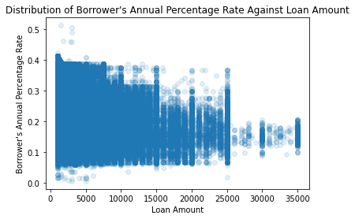

## (Visualization 2)

> Plot a box plot to show the relationship between prosper score and annual percentage rate.

> Low prosper score has high annual percentage rate while high prosper score has low annual percentage rate. This means people with high credit worthiness pay lower interest rate than those with low credit worthiness.

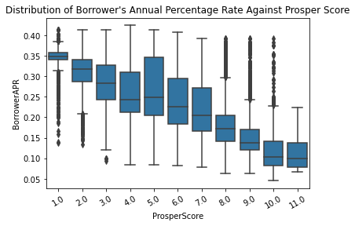

## (Visualization 3)

> Facet grid showing the relationship between borrower's annual percentage rate and loan term.

> More people fall in the 36 months loan category, however the annual percentage rate is higher for the 36 months loan stretching beyond 0.4 while the annual percentage interest rate for 60 months loan term is lower. This opposed the hypothesis i had that higher loan term means higher interest rate.

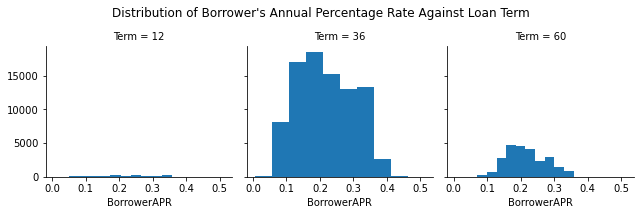

## (Visualization 4)

> plot matrix showing the relationship between annual percentage rate, interest rate and loan amount.

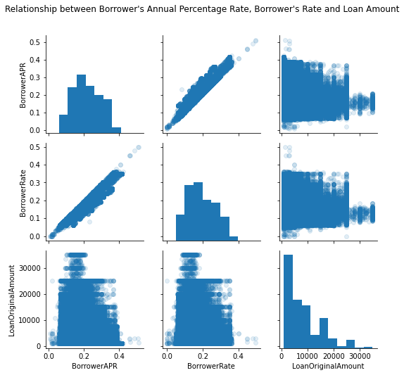